fossil

# Adverse drug reaction prediction, dug back up.

The authors' pipeline was never released. We rebuilt it from the paper and reran it on their own training file: 832 drugs, 1,385 ADRs and their folds. Of 36 results, 3 came back exact, 25 agree, 5 partly, 0 differ and 3 were not attempted.

See every resultSee the tables

## Install adrfusion

Python package

```
pip install "git+https://github.com/jeonglab-bcm/fossil#subdirectory=PMC3392844/package"
```

Python 3.10 or later; NumPy, SciPy and scikit-learn.

[README](https://github.com/jeonglab-bcm/fossil/blob/main/PMC3392844/package/README.md) [Tutorial](https://github.com/jeonglab-bcm/fossil/blob/main/PMC3392844/package/tutorial/TUTORIAL.md)

## Fig. 2

Fig. 2. ROC curves in fivefold cross-validation of the SVM on six feature sets, all 1,385 ADRs.

Agrees

Published

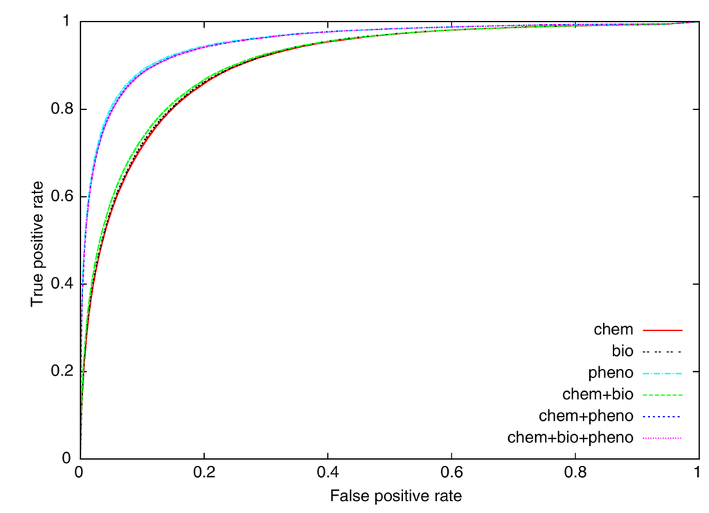

Our run

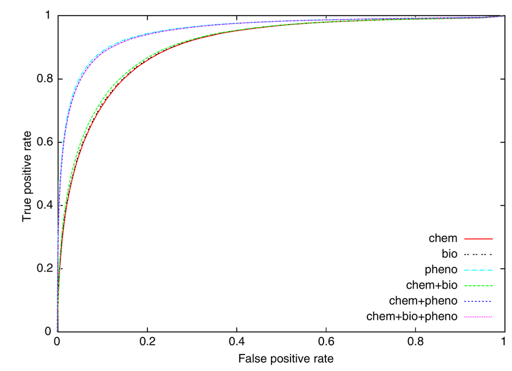

**Fig. 2, ROC curves of six feature sets, all ADRs (drawn)**

100.00% within 2 px (pass 95.0%, best control 56.0%), Agrees

**Fig. 2, ROC curves of six feature sets, all ADRs, TPR at five FPRs read from the vector curves**

30 of 30 fields as printed, Agrees

Every curve overlays the published one.

## Fig. 3

Fig. 3. The same over the common ADRs (ADR_50+).

Agrees

Published

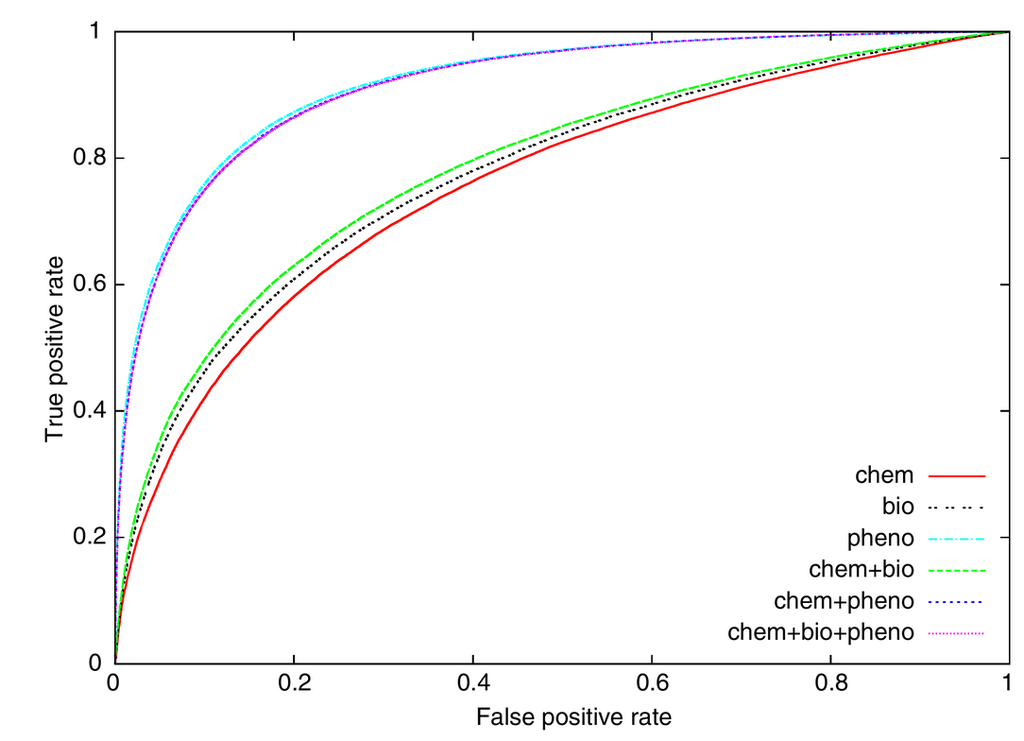

Our run

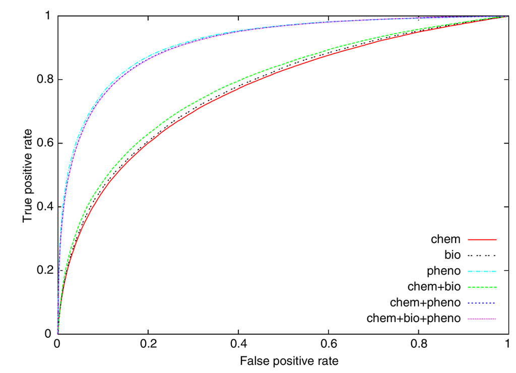

**Fig. 3, ROC curves of six feature sets, ADR_50+ (drawn)**

87.04% within 2 px (pass 95.0%, best control 37.5%), Agrees

**Fig. 3, ROC curves of six feature sets, ADR_50+, TPR at five FPRs read from the vector curves**

26 of 30 fields as printed, Agrees

curves within 2 px: chem 19.0%, bio 99.0%, pheno 100.0%, chem+bio 99.9%, chem+pheno 100.0%, chem+bio+pheno 100.0%. The published chem curve has area 0.7558; Table 2 prints 0.7659, ours 0.7658.

## Fig. 4

Fig. 4. ROC curves of five algorithms on the full feature set, all ADRs.

Agrees

Published

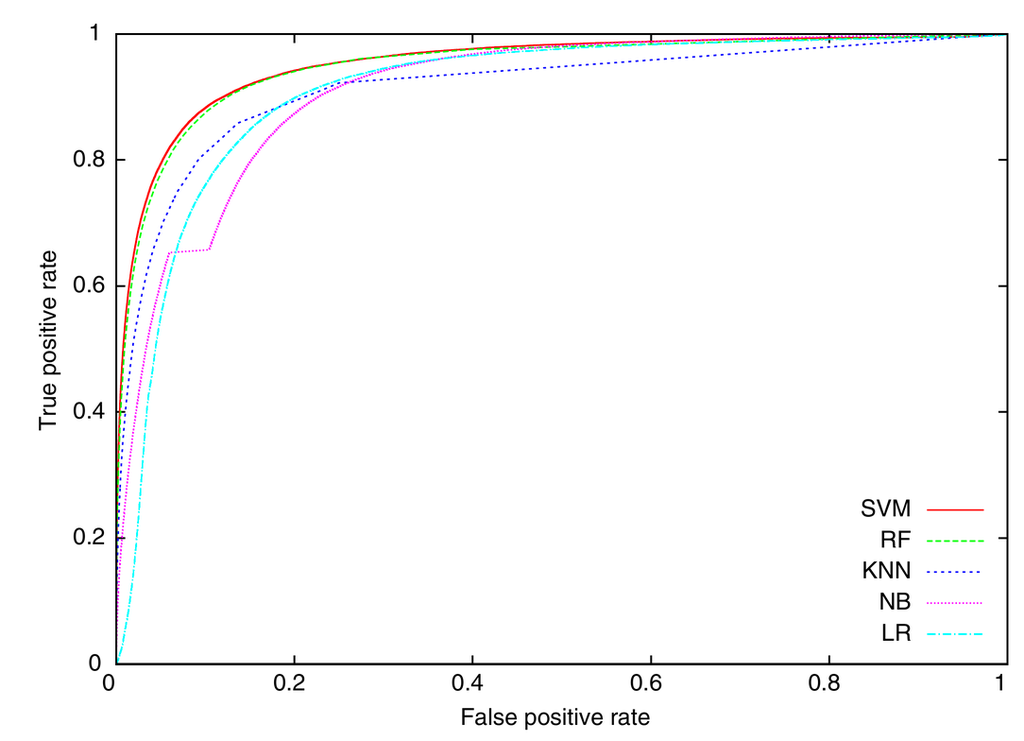

Our run

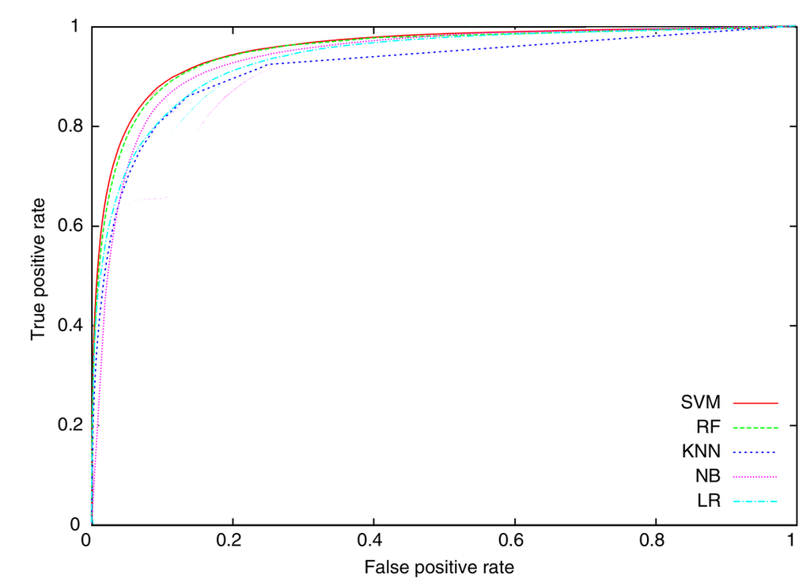

**Fig. 4, ROC curves of five algorithms (drawn)**

77.36% within 2 px (pass 95.0%, best control 50.8%), Agrees

**Fig. 4, ROC curves of five algorithms, TPR at five FPRs read from the vector curves**

17 of 25 fields as printed, Agrees

curves within 2 px: svm 100.0%, rf 99.9%, knn 100.0%, nb 45.3%, lr 47.2%. NB and LR as in Table 3.

## Table 1, feature dimensions

Feature dimensions of the recovered training file. Paper above, ours below; shaded where ours differs at the printed precision. 7 of 7 cells.

Exact

|  | Dimension |
| --- | --- |
| Substructures | 881 881 |
| Targets | 786 786 |
| Transporters | 72 72 |
| Enzymes | 111 111 |
| Pathways | 173 173 |
| Treatment indications | 869 869 |
| Other side effects | 1384 1384 |

## Table 2, the SVM by feature set

Micro-averaged over all ADRs and over ADR_50+. Paper above, ours below; shaded where ours differs at the printed precision. 6 of 48 cells.

Agrees

|  | All AUC | All ACC | All Prec. | All Recall | 50+ AUC | 50+ ACC | 50+ Prec. | 50+ Recall |
| --- | --- | --- | --- | --- | --- | --- | --- | --- |
| chem | 0.9054 0.9054 | 0.9538 0.9539 | 0.4337 0.4332 | 0.4925 0.4948 | 0.7659 0.7658 | 0.8268 0.8261 | 0.4539 0.4513 | 0.5569 0.5619 |
| bio | 0.9069 0.9068 | 0.9543 0.9543 | 0.4324 0.4344 | 0.5043 0.4995 | 0.7729 0.7724 | 0.8287 0.8280 | 0.4666 0.4641 | 0.5521 0.5568 |
| pheno | 0.9542 0.9544 | 0.9678 0.9678 | 0.6607 0.6526 | 0.6460 0.6546 | 0.9175 0.9175 | 0.8891 0.8887 | 0.6933 0.6918 | 0.7142 0.7174 |
| chem+bio | 0.9098 0.9099 | 0.9551 0.9552 | 0.4623 0.4514 | 0.5008 0.5132 | 0.7849 0.7848 | 0.8327 0.8321 | 0.4776 0.4728 | 0.5728 0.5801 |
| chem+pheno | 0.9526 0.9527 | 0.9669 0.9669 | 0.6488 0.6532 | 0.6443 0.6401 | 0.9141 0.9140 | 0.8857 0.8852 | 0.6757 0.6765 | 0.7215 0.7225 |
| chem+bio+pheno | 0.9524 0.9525 | 0.9669 0.9669 | 0.6617 0.6531 | 0.6306 0.6384 | 0.9138 0.9137 | 0.8856 0.8851 | 0.6750 0.6751 | 0.7227 0.7228 |

5 of 24 fields at printed precision; largest gap chem+bio|all|recall: 0.513183 against 0.5008. Every AUC within 0.0005 and every precision and recall within 0.0124 of the paper. Over four seeds of the SVM's probability fit our AUCs move by up to 0.0003 and precision and recall by up to 0.0249; the paper's value lies inside our seed range in 26 of 48 Table 2 cells. The rest of the gap is not explained: the official LIBSVM build was tested and does not close it. 1 of 24 fields at printed precision; largest gap chem+bio|50+|recall: 0.580091 against 0.5728. Every AUC within 0.0005 and every precision and recall within 0.0124 of the paper. Over four seeds of the SVM's probability fit our AUCs move by up to 0.0003 and precision and recall by up to 0.0249; the paper's value lies inside our seed range in 26 of 48 Table 2 cells. The rest of the gap is not explained: the official LIBSVM build was tested and does not close it.

## Table 3, five algorithms on the full feature set

Micro-averaged over all ADRs and over ADR_50+. Paper above, ours below; shaded where ours differs at the printed precision. 4 of 40 cells.

Agrees

|  | All AUC | All ACC | All Prec. | All Recall | 50+ AUC | 50+ ACC | 50+ Prec. | 50+ Recall |
| --- | --- | --- | --- | --- | --- | --- | --- | --- |
| lr | 0.9102 0.9337 | 0.9486 0.9640 | 0.4152 0.5916 | 0.5671 0.5779 | 0.7648 0.8788 | 0.8023 0.8728 | 0.5321 0.6341 | 0.6908 0.6734 |
| nb | 0.9116 0.9358 | 0.9527 0.9536 | 0.3537 0.4726 | 0.6302 0.6460 | 0.8627 0.8618 | 0.8431 0.8421 | 0.3929 0.5299 | 0.7214 0.7164 |
| knn | 0.9161 0.9161 | 0.9595 0.9596 | 0.5300 0.5300 | 0.5787 0.5788 | 0.8508 0.8507 | 0.8530 0.8524 | 0.5633 0.5633 | 0.6401 0.6413 |
| rf | 0.9491 0.9488 | 0.9653 0.9651 | 0.6310 0.6300 | 0.6250 0.6191 | 0.9052 0.9041 | 0.8784 0.8768 | 0.6522 0.6513 | 0.7057 0.7009 |
| svm | 0.9524 0.9525 | 0.9669 0.9669 | 0.6617 0.6531 | 0.6306 0.6384 | 0.9141 0.9137 | 0.8857 0.8851 | 0.6750 0.6751 | 0.7227 0.7228 |

0 of 8 fields at printed precision; largest gap lr|all|precision: 0.59159 against 0.4152. No LIBLINEAR setting tried gives the paper's row. 0 of 8 fields at printed precision; largest gap nb|50+|precision: 0.529946 against 0.3929. CLOP's naive Bayes settings are not stated. 3 of 8 fields at printed precision; largest gap knn|50+|recall: 0.641302 against 0.6401. WEKA's neighbour search order cannot be replayed exactly. 0 of 8 fields at printed precision; largest gap rf|all|recall: 0.619137 against 0.625. Not explained: two scikit-learn seeds differ by 0.0002 in AUC and both fall below the paper; WEKA itself was not rerun. 1 of 8 fields at printed precision; largest gap svm|all|precision: 0.653118 against 0.6617. Every AUC within 0.0005 and every precision and recall within 0.0124 of the paper. Over four seeds of the SVM's probability fit our AUCs move by up to 0.0003 and precision and recall by up to 0.0249; the paper's value lies inside our seed range in 26 of 48 Table 2 cells. The rest of the gap is not explained: the official LIBSVM build was tested and does not close it.

## Table 4, clinical validation calls (cerivastatin, rofecoxib)

Yes or No: is the withdrawn drug predicted to have the ADR, with every other drug as the training set. Paper above, ours below; shaded where ours differs at the printed precision. 36 of 39 cells.

Agrees

|  | chem | chem+bio | chem+bio+pheno |
| --- | --- | --- | --- |
| Cerivastatin Rhabdomyolysis | No No | Yes Yes | Yes Yes |
| Cerivastatin Myopathy | No Yes | Yes Yes | Yes Yes |
| Cerivastatin Myositis | No No | Yes No | Yes Yes |
| Cerivastatin Myalgia | Yes Yes | Yes Yes | Yes Yes |
| Cerivastatin Muscle cramps | No No | Yes Yes | Yes Yes |
| Cerivastatin Dermatomyositis | No No | No No | No No |
| Cerivastatin Myoglobinuria | No No | No No | No No |
| Cerivastatin Group above ADRs | Yes Yes | Yes Yes | Yes Yes |
| Rofecoxib Myocardial infarction | No No | No No | Yes Yes |
| Rofecoxib Chest pain | No No | No No | Yes Yes |
| Rofecoxib Atrial fibrillation | No No | No No | No No |
| Rofecoxib Congestive heart failure | No No | No No | No No |
| Rofecoxib Group above ADRs | Yes No | Yes Yes | Yes Yes |

36 of 39 fields at printed precision; not: Cerivastatin|Myopathy|chem, Cerivastatin|Myositis|chem+bio, Rofecoxib|Group above ADRs|chem. The paper does not state the decision threshold.

## Fig. 5, overlap of true positives of chem, bio and pheno

Regions of the Venn diagram of Fig. 5. Paper above, ours below; shaded where ours differs at the printed precision. 0 of 7 cells.

Agrees

|  | True positives |
| --- | --- |
| chem | 928 935 |
| chem&bio | 3260 3073 |
| bio | 884 804 |
| chem&bio&pheno | 23025 23171 |
| chem&pheno | 1950 2115 |
| bio&pheno | 2688 2522 |
| pheno | 10581 10944 |

0 of 7 fields at printed precision; largest gap pheno: 10944 against 10581. Counts at the max-F1 points move with the precision and recall cells.

## Table S1, share of informative features (chi-square p < 0.05)

Share of all informative (feature, ADR) pairs, by feature block. Paper above, ours below; shaded where ours differs at the printed precision. 1 of 7 cells.

Partly agrees

|  | % |
| --- | --- |
| chem | 5.0 10.9 |
| target | 5.7 5.7 |
| transporter | 0.5 0.8 |
| enzyme | 1.0 1.4 |
| pathway | 1.7 2.2 |
| indication | 7.7 10.1 |
| ade | 78.4 68.9 |

1 of 7 fields at printed precision; largest gap ade: 68.9011 against 78.4. Counting rule unstated.

## Every result

Each figure, table and claim of the paper, with the verdict results.json computes from the numbers.

Result

Verdict

Measure

Why

Fig. 1, the surveillance framework

Not attempted

not attempted

A diagram.

Table 1, feature dimensions

Exact

7 of 7 fields as printed

- Substructures: paper 881, ours **881**
- Targets: paper 786, ours **786**
- Transporters: paper 72, ours **72**
- Enzymes: paper 111, ours **111**
- Pathways: paper 173, ours **173**
- Treatment indications: paper 869, ours **869**
- Other side effects: paper 1384, ours **1384**

Table 2, SVM by feature set, all ADRs

Agrees

5 of 24 fields as printed

5 of 24 fields at printed precision; largest gap chem+bio|all|recall: 0.513183 against 0.5008. Every AUC within 0.0005 and every precision and recall within 0.0124 of the paper. Over four seeds of the SVM's probability fit our AUCs move by up to 0.0003 and precision and recall by up to 0.0249; the paper's value lies inside our seed range in 26 of 48 Table 2 cells. The rest of the gap is not explained: the official LIBSVM build was tested and does not close it.

Table 2, SVM by feature set, ADR_50+

Agrees

1 of 24 fields as printed

1 of 24 fields at printed precision; largest gap chem+bio|50+|recall: 0.580091 against 0.5728. Every AUC within 0.0005 and every precision and recall within 0.0124 of the paper. Over four seeds of the SVM's probability fit our AUCs move by up to 0.0003 and precision and recall by up to 0.0249; the paper's value lies inside our seed range in 26 of 48 Table 2 cells. The rest of the gap is not explained: the official LIBSVM build was tested and does not close it.

Table 3, SVM row

Agrees

1 of 8 fields as printed

- svm|all|auc: paper 0.9524, ours **0.9525**
- svm|all|acc: paper 0.9669, ours **0.9669**
- svm|all|precision: paper 0.6617, ours **0.6531**
- svm|all|recall: paper 0.6306, ours **0.6384**
- svm|50+|auc: paper 0.9141, ours **0.9137**
- svm|50+|acc: paper 0.8857, ours **0.8851**
- svm|50+|precision: paper 0.6750, ours **0.6751**
- svm|50+|recall: paper 0.7227, ours **0.7228**

1 of 8 fields at printed precision; largest gap svm|all|precision: 0.653118 against 0.6617. Every AUC within 0.0005 and every precision and recall within 0.0124 of the paper. Over four seeds of the SVM's probability fit our AUCs move by up to 0.0003 and precision and recall by up to 0.0249; the paper's value lies inside our seed range in 26 of 48 Table 2 cells. The rest of the gap is not explained: the official LIBSVM build was tested and does not close it.

Table 3, RF row

Agrees

0 of 8 fields as printed

- rf|all|auc: paper 0.9491, ours **0.9488**
- rf|all|acc: paper 0.9653, ours **0.9651**
- rf|all|precision: paper 0.6310, ours **0.6300**
- rf|all|recall: paper 0.6250, ours **0.6191**
- rf|50+|auc: paper 0.9052, ours **0.9041**
- rf|50+|acc: paper 0.8784, ours **0.8768**
- rf|50+|precision: paper 0.6522, ours **0.6513**
- rf|50+|recall: paper 0.7057, ours **0.7009**

0 of 8 fields at printed precision; largest gap rf|all|recall: 0.619137 against 0.625. Not explained: two scikit-learn seeds differ by 0.0002 in AUC and both fall below the paper; WEKA itself was not rerun.

Table 3, KNN row

Agrees

3 of 8 fields as printed

- knn|all|auc: paper 0.9161, ours **0.9161**
- knn|all|acc: paper 0.9595, ours **0.9596**
- knn|all|precision: paper 0.5300, ours **0.5300**
- knn|all|recall: paper 0.5787, ours **0.5788**
- knn|50+|auc: paper 0.8508, ours **0.8507**
- knn|50+|acc: paper 0.8530, ours **0.8524**
- knn|50+|precision: paper 0.5633, ours **0.5633**
- knn|50+|recall: paper 0.6401, ours **0.6413**

3 of 8 fields at printed precision; largest gap knn|50+|recall: 0.641302 against 0.6401. WEKA's neighbour search order cannot be replayed exactly.

Table 3, NB row

Agrees

0 of 8 fields as printed

- nb|all|auc: paper 0.9116, ours **0.9358**
- nb|all|acc: paper 0.9527, ours **0.9536**
- nb|all|precision: paper 0.3537, ours **0.4726**
- nb|all|recall: paper 0.6302, ours **0.6460**
- nb|50+|auc: paper 0.8627, ours **0.8618**
- nb|50+|acc: paper 0.8431, ours **0.8421**
- nb|50+|precision: paper 0.3929, ours **0.5299**
- nb|50+|recall: paper 0.7214, ours **0.7164**

0 of 8 fields at printed precision; largest gap nb|50+|precision: 0.529946 against 0.3929. CLOP's naive Bayes settings are not stated.

Table 3, LR row

Agrees

0 of 8 fields as printed

- lr|all|auc: paper 0.9102, ours **0.9337**
- lr|all|acc: paper 0.9486, ours **0.9640**
- lr|all|precision: paper 0.4152, ours **0.5916**
- lr|all|recall: paper 0.5671, ours **0.5779**
- lr|50+|auc: paper 0.7648, ours **0.8788**
- lr|50+|acc: paper 0.8023, ours **0.8728**
- lr|50+|precision: paper 0.5321, ours **0.6341**
- lr|50+|recall: paper 0.6908, ours **0.6734**

0 of 8 fields at printed precision; largest gap lr|all|precision: 0.59159 against 0.4152. No LIBLINEAR setting tried gives the paper's row.

Fig. 2, ROC curves of six feature sets, all ADRs (drawn)

Agrees

100.00% within 2 px (pass 95.0%, best control 56.0%)

Fig. 2, ROC curves of six feature sets, all ADRs, TPR at five FPRs read from the vector curves

Agrees

30 of 30 fields as printed

Fig. 3, ROC curves of six feature sets, ADR_50+ (drawn)

Agrees

87.04% within 2 px (pass 95.0%, best control 37.5%)

curves within 2 px: chem 19.0%, bio 99.0%, pheno 100.0%, chem+bio 99.9%, chem+pheno 100.0%, chem+bio+pheno 100.0%. The published chem curve has area 0.7558; Table 2 prints 0.7659, ours 0.7658.

Fig. 3, ROC curves of six feature sets, ADR_50+, TPR at five FPRs read from the vector curves

Agrees

26 of 30 fields as printed

26 of 30 fields at printed precision; largest gap chem at FPR 0.05: 0.321346 against 0.2899. The published chem curve has area 0.7558; Table 2 prints 0.7659, ours 0.7658.

Fig. 4, ROC curves of five algorithms (drawn)

Agrees

77.36% within 2 px (pass 95.0%, best control 50.8%)

curves within 2 px: svm 100.0%, rf 99.9%, knn 100.0%, nb 45.3%, lr 47.2%. NB and LR as in Table 3.

Fig. 4, ROC curves of five algorithms, TPR at five FPRs read from the vector curves

Agrees

17 of 25 fields as printed

17 of 25 fields at printed precision; largest gap lr at FPR 0.01: 0.475163 against 0.0531. NB and LR as in Table 3.

Fig. 5, overlap of true positives of chem, bio and pheno

Agrees

0 of 7 fields as printed

- chem: paper 928, ours **935**
- chem&bio: paper 3260, ours **3073**
- bio: paper 884, ours **804**
- chem&bio&pheno: paper 23025, ours **23171**
- chem&pheno: paper 1950, ours **2115**
- bio&pheno: paper 2688, ours **2522**
- pheno: paper 10581, ours **10944**

0 of 7 fields at printed precision; largest gap pheno: 10944 against 10581. Counts at the max-F1 points move with the precision and recall cells.

Table 4, clinical validation calls (cerivastatin, rofecoxib)

Agrees

36 of 39 fields as printed

36 of 39 fields at printed precision; not: Cerivastatin|Myopathy|chem, Cerivastatin|Myositis|chem+bio, Rofecoxib|Group above ADRs|chem. The paper does not state the decision threshold.

Table S1, share of informative features (chi-square p < 0.05)

Partly agrees

1 of 7 fields as printed

- chem: paper 5.0, ours **10.9**
- target: paper 5.7, ours **5.7**
- transporter: paper 0.5, ours **0.8**
- enzyme: paper 1.0, ours **1.4**
- pathway: paper 1.7, ours **2.2**
- indication: paper 7.7, ours **10.1**
- ade: paper 78.4, ours **68.9**

1 of 7 fields at printed precision; largest gap ade: 68.9011 against 78.4. Counting rule unstated.

SIDER: 888 drugs, 1385 side-effect terms, 61 102 associations, 68.8 side effects per drug

Exact

4 of 4 fields as printed

- drugs: paper 888, ours **888**
- side-effect terms: paper 1385, ours **1385**
- associations: paper 61102, ours **61102**
- side effects per drug: paper 68.8, ours **68.8**

832 drugs (56 of SIDER's 888 unmapped) with 1385 ADRs; 4276 = 881 + 1142 + 2253 features

Exact

5 of 5 fields as printed

- drugs: paper 832, ours **832**
- ADRs: paper 1385, ours **1385**
- features: paper 4276, ours **4276**
- biological features: paper 1142, ours **1142**
- phenotypic features: paper 2253, ours **2253**

Main claim: adding biological and phenotypic features to chemical structures raises AUC from 0.9054 to 0.9524, precision from 43.37% to 66.17% and recall from 49.25% to 63.06%

Agrees

1 of 6 fields as printed

- auc chem: paper 0.9054, ours **0.9054**
- auc chem+bio+pheno: paper 0.9524, ours **0.9525**
- precision chem: paper 43.37, ours **43.32**
- precision chem+bio+pheno: paper 66.17, ours **65.31**
- recall chem: paper 49.25, ours **49.48**
- recall chem+bio+pheno: paper 63.06, ours **63.84**

1 of 6 fields at printed precision; largest gap precision chem+bio+pheno: 65.3118 against 66.17. Every AUC within 0.0005 and every precision and recall within 0.0124 of the paper. Over four seeds of the SVM's probability fit our AUCs move by up to 0.0003 and precision and recall by up to 0.0249; the paper's value lies inside our seed range in 26 of 48 Table 2 cells. The rest of the gap is not explained: the official LIBSVM build was tested and does not close it.

Feature assessment: pheno has the highest AUC alone; adding bio raises AUC by 0.004 (0.02 for ADR_50+), precision by ~3% and recall by ~1%; adding pheno raises precision by ~21% and recall by ~15%

Agrees

6 of 7 fields as printed

- pheno has the highest AUC of the single feature sets: paper yes, ours **yes**
- AUC gain of bio, all ADRs: paper 0.004, ours **0.004**
- AUC gain of bio, ADR_50+: paper 0.02, ours **0.02**
- precision gain of bio (about, points): paper 3, ours **2**
- recall gain of bio (about, points): paper 1, ours **2**
- precision gain of pheno (about, points): paper 21, ours **22**
- recall gain of pheno (about, points): paper 15, ours **15**

6 of 7 fields at printed precision; largest gap precision gain of bio (about, points): 1.81855 against 3. Every AUC within 0.0005 and every precision and recall within 0.0124 of the paper. Over four seeds of the SVM's probability fit our AUCs move by up to 0.0003 and precision and recall by up to 0.0249; the paper's value lies inside our seed range in 26 of 48 Table 2 cells. The rest of the gap is not explained: the official LIBSVM build was tested and does not close it.

KS tests on per-ADR AUCs (Bonferroni-corrected): chem to chem+bio p = 1.45E-07 and chem to chem+bio+pheno p = 1.10E-15, both significant; the drop from pheno to chem+bio+pheno is not (p = 0.177)

Partly agrees

3 of 6 fields as printed

- chem to chem+bio, log10 p: paper -6.84, ours **-6.05**
- chem to chem+bio+pheno, log10 p: paper -14.96, ours **-188.91**
- pheno to chem+bio+pheno, log10 p: paper -0.75, ours **-0.65**
- chem to chem+bio significant: paper yes, ours **yes**
- chem to chem+bio+pheno significant: paper yes, ours **yes**
- pheno to chem+bio+pheno significant: paper no, ours **no**

3 of 6 fields at printed precision; largest gap chem to chem+bio+pheno, log10 p: -188.915 against -14.96. All three significance calls match; the p-values depend on the per-ADR AUCs and the unstated test variant.

chem+bio+pheno has a lower global AUC than pheno alone, and its ROC curve almost overlaps that of chem+pheno

Agrees

2 of 2 fields as printed

- chem+bio+pheno below pheno: paper yes, ours **yes**
- chem+bio+pheno within 0.001 AUC of chem+pheno: paper yes, ours **yes**

Over the common ADRs (ADR_50+) AUC and accuracy fall for every feature set, and the curves separate more

Agrees

7 of 7 fields as printed

- chem: AUC and ACC lower over ADR_50+: paper yes, ours **yes**
- bio: AUC and ACC lower over ADR_50+: paper yes, ours **yes**
- pheno: AUC and ACC lower over ADR_50+: paper yes, ours **yes**
- chem+bio: AUC and ACC lower over ADR_50+: paper yes, ours **yes**
- chem+pheno: AUC and ACC lower over ADR_50+: paper yes, ours **yes**
- chem+bio+pheno: AUC and ACC lower over ADR_50+: paper yes, ours **yes**
- AUC range of the six sets wider over ADR_50+: paper yes, ours **yes**

Method comparison: SVM performs best, followed by RF, KNN, NB and LR; SVM's precision (66.17%) and recall (63.06%) beat RF's (63.10%, 62.50%)

Partly agrees

3 of 4 fields as printed

- order by AUC over all ADRs: paper SVM>RF>KNN>NB>LR, ours **SVM>RF>NB>LR>KNN**
- SVM has the highest AUC: paper yes, ours **yes**
- SVM precision above RF's: paper yes, ours **yes**
- SVM recall above RF's: paper yes, ours **yes**

3 of 4 fields at printed precision; not: order by AUC over all ADRs. LR and NB rows differ (see Table 3).

Discussion: indications alone added to chemical structures raise AUC from 0.9054 to 0.9110

Agrees

0 of 1 fields as printed

- AUC of chem+indication: paper 0.9110, ours **0.9111**

0 of 1 fields at printed precision; largest gap AUC of chem+indication: 0.911063 against 0.911. AUC 0.9111 against 0.9110, a gap smaller than the seed range of our AUCs (0.0003).

Discussion: class weights (1 - class share) raise RF's AUC from 0.9491 to 0.9524; SVM does not improve

Partly agrees

1 of 3 fields as printed

- AUC of weighted RF: paper 0.9524, ours **0.9483**
- weights raise RF's AUC: paper yes, ours **no**
- weights do not raise SVM's AUC: paper yes, ours **yes**

1 of 3 fields at printed precision; largest gap AUC of weighted RF: 0.948334 against 0.9524. Weighted RF AUC 0.9483 against unweighted 0.9488.

Discussion: nausea and headache co-occur in 596 drugs; 49 pairs of ADRs co-occur in more than 400 drugs; 554 ADRs have fewer than five drugs (about 1:166 positives to negatives)

Agrees

1 of 4 fields as printed

- drugs with nausea and headache: paper 596, ours **598**
- ADR pairs in more than 400 drugs: paper 49, ours **50**
- ADRs with fewer than five drugs: paper 554, ours **560**
- negatives per positive at five drugs: paper 166, ours **166**

1 of 4 fields at printed precision; largest gap ADRs with fewer than five drugs: 560 against 554. Counts on the 832-drug file differ slightly.

Clinical validation: chem detects 1 of 7 rhabdomyolysis ADRs and 0 of 4 heart-attack ADRs, chem+bio 5 and 0, chem+bio+pheno 5 and 2; every classifier detects both grouped ADRs

Partly agrees

4 of 7 fields as printed

- Cerivastatin detected by chem: paper 1, ours **2**
- Rofecoxib detected by chem: paper 0, ours **0**
- Cerivastatin detected by chem+bio: paper 5, ours **4**
- Rofecoxib detected by chem+bio: paper 0, ours **0**
- Cerivastatin detected by chem+bio+pheno: paper 5, ours **5**
- Rofecoxib detected by chem+bio+pheno: paper 2, ours **2**
- both groups detected by every feature set: paper yes, ours **no**

4 of 7 fields at printed precision; largest gap Cerivastatin detected by chem: 2 against 1. The paper does not state the decision threshold.

Discussion and Fig. 5: 5072 true positives come from chem or bio but not pheno, 10 581 from pheno alone

Agrees

0 of 2 fields as printed

- chem or bio, not pheno: paper 5072, ours **4812**
- pheno only: paper 10581, ours **10944**

0 of 2 fields at printed precision; largest gap pheno only: 10944 against 10581. Counts at the max-F1 points move with the precision and recall cells.

Chem-only AUC 0.9054 'similar to' Pauwels et al.'s 0.8930

Not attempted

not attempted

0.8930 is Pauwels et al.'s result; our chem AUC is in Table 2.

Claims recomputed from the paper's own tables

Agrees

44 of 44 statements follow from the paper's own tables and figures.

The recovered training file is the paper's

Agrees

The recovered file has 59,205 positive (drug, ADR) pairs; Fig. 5's true positives over Table 2's recalls imply chem 59,214, bio 59,205, pheno 59,201, all within 0.1%.

The authors' code

Not attempted

not attempted

Never released (fossil issue #93 lists the search). Rebuilt from the text as adrfusion and checked against the paper only.

Python package adrfusion and its tutorial

Agrees

adrfusion 0.1.0: wheel installed in a fresh environment and imported from it; tests 6 passed; tutorial 6 cells compared, 0 skipped (nondeterministic); TUTORIAL.md in sync

The main claim holds: in our run adding biological and phenotypic features to chemical structures raises AUC from 0.9054 to 0.9525, precision from 43.32% to 65.31% and recall from 49.48% to 63.84% (paper 0.9054 to 0.9524, 43.37% to 66.17%, 49.25% to 63.06%). The claims that do not match come from the unstated variant of the KS test, the LR and NB settings, the class weighting of RF (our AUC falls) and the unstated threshold of Table 4.

## What came back

**Table 1, feature dimensions**

7 of 7 fields as printed

**Table 2, SVM by feature set, all ADRs**

5 of 24 fields as printed

**Table 2, SVM by feature set, ADR_50+**

1 of 24 fields as printed

**Table 3, SVM row**

1 of 8 fields as printed

**Table 3, RF row**

0 of 8 fields as printed

**Table 3, KNN row**

3 of 8 fields as printed

**Table 3, NB row**

0 of 8 fields as printed

**Table 3, LR row**

0 of 8 fields as printed

**Fig. 2, ROC curves of six feature sets, all ADRs (drawn)**

100.00% within 2 px (pass 95.0%, best control 56.0%)

**Fig. 2, ROC curves of six feature sets, all ADRs, TPR at five FPRs read from the vector curves**

30 of 30 fields as printed

**Fig. 3, ROC curves of six feature sets, ADR_50+ (drawn)**

87.04% within 2 px (pass 95.0%, best control 37.5%)

**Fig. 3, ROC curves of six feature sets, ADR_50+, TPR at five FPRs read from the vector curves**

26 of 30 fields as printed

**Fig. 4, ROC curves of five algorithms (drawn)**

77.36% within 2 px (pass 95.0%, best control 50.8%)

**Fig. 4, ROC curves of five algorithms, TPR at five FPRs read from the vector curves**

17 of 25 fields as printed

**Fig. 5, overlap of true positives of chem, bio and pheno**

0 of 7 fields as printed

**Table 4, clinical validation calls (cerivastatin, rofecoxib)**

36 of 39 fields as printed

**SIDER: 888 drugs, 1385 side-effect terms, 61 102 associations, 68.8 side effects per drug**

4 of 4 fields as printed

**832 drugs (56 of SIDER's 888 unmapped) with 1385 ADRs; 4276 = 881 + 1142 + 2253 features**

5 of 5 fields as printed

**Main claim: adding biological and phenotypic features to chemical structures raises AUC from 0.9054 to 0.9524, precision from 43.37% to 66.17% and recall from 49.25% to 63.06%**

1 of 6 fields as printed

**Feature assessment: pheno has the highest AUC alone; adding bio raises AUC by 0.004 (0.02 for ADR_50+), precision by ~3% and recall by ~1%; adding pheno raises precision by ~21% and recall by ~15%**

6 of 7 fields as printed

**chem+bio+pheno has a lower global AUC than pheno alone, and its ROC curve almost overlaps that of chem+pheno**

2 of 2 fields as printed

**Over the common ADRs (ADR_50+) AUC and accuracy fall for every feature set, and the curves separate more**

7 of 7 fields as printed

**Discussion: indications alone added to chemical structures raise AUC from 0.9054 to 0.9110**

0 of 1 fields as printed

**Discussion: nausea and headache co-occur in 596 drugs; 49 pairs of ADRs co-occur in more than 400 drugs; 554 ADRs have fewer than five drugs (about 1:166 positives to negatives)**

1 of 4 fields as printed

**Discussion and Fig. 5: 5072 true positives come from chem or bio but not pheno, 10 581 from pheno alone**

0 of 2 fields as printed

**Claims recomputed from the paper's own tables**

44 of 44 statements follow from the paper's own tables and figures.

**The recovered training file is the paper's**

The recovered file has 59,205 positive (drug, ADR) pairs; Fig. 5's true positives over Table 2's recalls imply chem 59,214, bio 59,205, pheno 59,201, all within 0.1%.

**Python package adrfusion and its tutorial**

adrfusion 0.1.0: wheel installed in a fresh environment and imported from it; tests 6 passed; tutorial 6 cells compared, 0 skipped (nondeterministic); TUTORIAL.md in sync

## What stayed buried

- Table S1, share of informative features (chi-square p < 0.05): 1 of 7 fields as printed.
- KS tests on per-ADR AUCs (Bonferroni-corrected): chem to chem+bio p = 1.45E-07 and chem to chem+bio+pheno p = 1.10E-15, both significant; the drop from pheno to chem+bio+pheno is not (p = 0.177): 3 of 6 fields as printed.
- Method comparison: SVM performs best, followed by RF, KNN, NB and LR; SVM's precision (66.17%) and recall (63.06%) beat RF's (63.10%, 62.50%): 3 of 4 fields as printed.
- Discussion: class weights (1 - class share) raise RF's AUC from 0.9491 to 0.9524; SVM does not improve: 1 of 3 fields as printed.
- Clinical validation: chem detects 1 of 7 rhabdomyolysis ADRs and 0 of 4 heart-attack ADRs, chem+bio 5 and 0, chem+bio+pheno 5 and 2; every classifier detects both grouped ADRs: 4 of 7 fields as printed.

The main claim holds: in our run adding biological and phenotypic features to chemical structures raises AUC from 0.9054 to 0.9525, precision from 43.32% to 65.31% and recall from 49.48% to 63.84% (paper 0.9054 to 0.9524, 43.37% to 66.17%, 49.25% to 63.06%). The claims that do not match come from the unstated variant of the KS test, the LR and NB settings, the class weighting of RF (our AUC falls) and the unstated threshold of Table 4.

## What we matched

What the reproduction stands on.

**Data**

The authors' training file, from Zhang et al. 2015's supplement (CC BY 4.0): 832 drugs, every feature bit and the fold of each drug for each ADR.

**Method**

adrfusion, rebuilt from the paper's Methods: one classifier per ADR, LIBSVM's RBF kernel with g 0.008 and C 2, micro-averaged ROC.

**Figures**

The published ROC curves read from the PDF's vector paths, our curves drawn on the published frames at 600 dpi.

## The session

The reproduction was done by an AI agent, Claude Code, in one session. Every prompt, reply and tool call of it is published.

**Wall clock**

6.5 h

first message to last, waits included

**Human prompts**

5

messages typed by a person

**Tool calls**

258

12 of them in subagents

**Tokens**

84.3 M

every request, subagents included

Read the session [The raw files](https://github.com/jeonglab-bcm/fossil/tree/main/PMC3392844/session)